# Научная презентация по лабораторной работе №12

Дисциплина:Операционные системы

Абрамова У. М.

Российский университет дружбы народов, Москва, Россия

Математический институт имени Никольского, Москва, Россия

03.05.2025

# Информация

## Докладчик

- Абрамова Ульяна Михайловна
- Студент НММбд-01-24
- Российский университет дружбы народов
- 1132246782@pfur.ru
- https://github.com/Ulyana-abr

# Вводная часть

## Цели и задачи

- Изучить основы программирования в оболочке ОС UNIX/Linux.
- Научиться писать небольшие командные файлы.

## Материалы и методы

- fedora - linux

## Содержание исследования

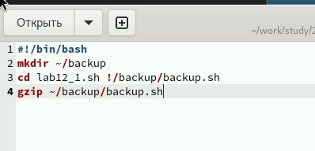

1

## Содержание исследования

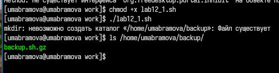

2

## Содержание исследования

2. Написали пример командного файла, обрабатывающего любое произвольное число аргументов командной строки, в том числе превышающее десять (рис. 3, 4).

## Содержание исследования

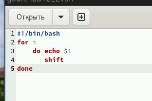

3

## Содержание исследования

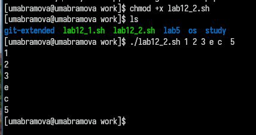

4

## Содержание исследования

3. Написали командный файл — аналог команды ls (без использования самой этой команды и команды dir ). Он выдает информацию о нужном каталоге и выводит информацию о возможностях доступа к файлам этого каталога (рис. 5, 6).

## Содержание исследования

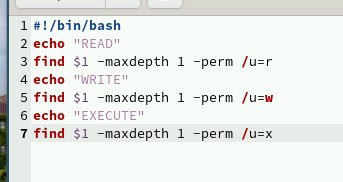

5

## Содержание исследования

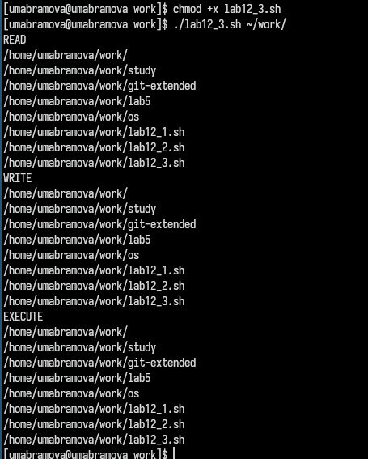

6

## Содержание исследования

4. Написали командный файл, который получает в качестве аргумента командной строки формат файла ( .txt , .doc , .jpg , .pdf и т.д.) и вычисляет количество таких файлов в указанной директории. Путь к директории также передаётся в виде аргумента командной строки (рис. 7, 8).

## Содержание исследования

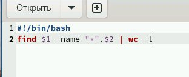

7

## Содержание исследования

[figure not shown]

8

## Результаты

- В данной работе мы изучили основы программирования в оболочке ОС UNIX/Linux. Научились писать небольшие командные файлы и скрипты на языке bush.

## Итоговый слайд

*Чем больше вы практикуетесь и пробуете новое, тем больше и чаще вы будете получать знаний и опыта в разных сферах.*